# Aggie subset data

2023-05-09

## sample summary

**click to open**

Soils were collected around trees on treelines in the western brooks range Alaska varying in soil moisture. Three sites were chosen: Tussock tundra (Mesic), Wet Sedge (Hydric), and Dryas-lichen tundra (Xeric). 8 similar trees were chosen per treatment based on their DBH and proximity to the treeline. Snow fences were constructed as a treatment to build larger snow packs around the given trees in winter and compared against a control group where nothing was done besides sampling. In order to reduce impact on these tree-plots 8 Ancillary trees were also chosen based on the same DBH, proximity to treeline parameters and used for seasonal sampling.  
A previous project conducted at these sites fertilized soils around similar trees. These soils were also sampled to identify long term effects of fertilization. Soils were collected from control and snowfence trees in march and late may/early June (Just after thaw) along with resin strips (Except in 2020). Soil pore water was taken regularly during the growing season (2017-2019). During 2019 collection frequencies reduced due to staffing and were disrupted due to COVID in 2020 with an inability to visit the field sites.

## Soil temperature

**click to open**

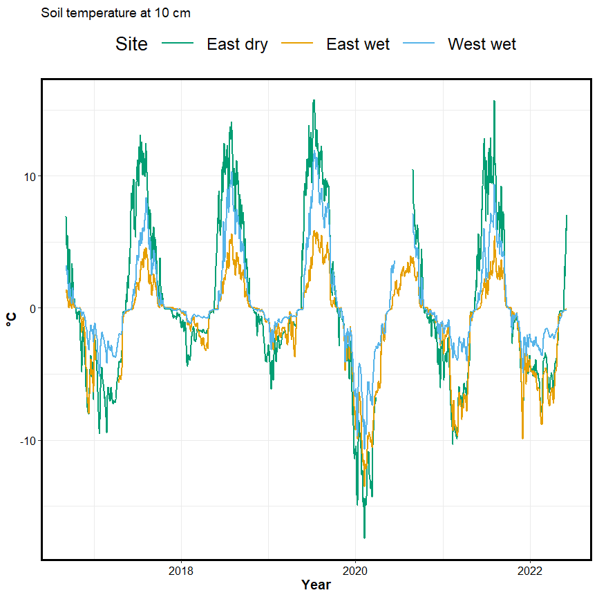

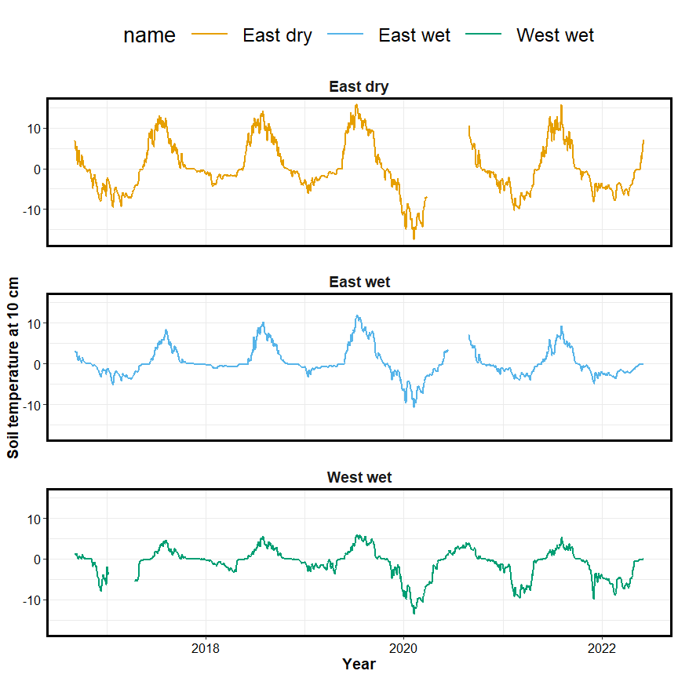

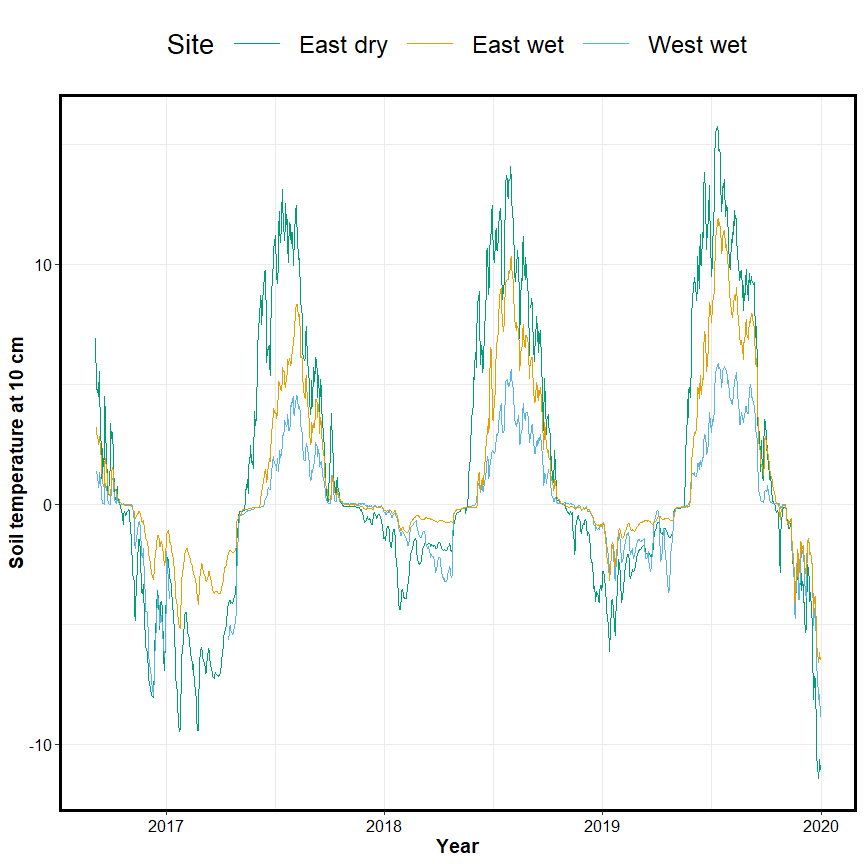

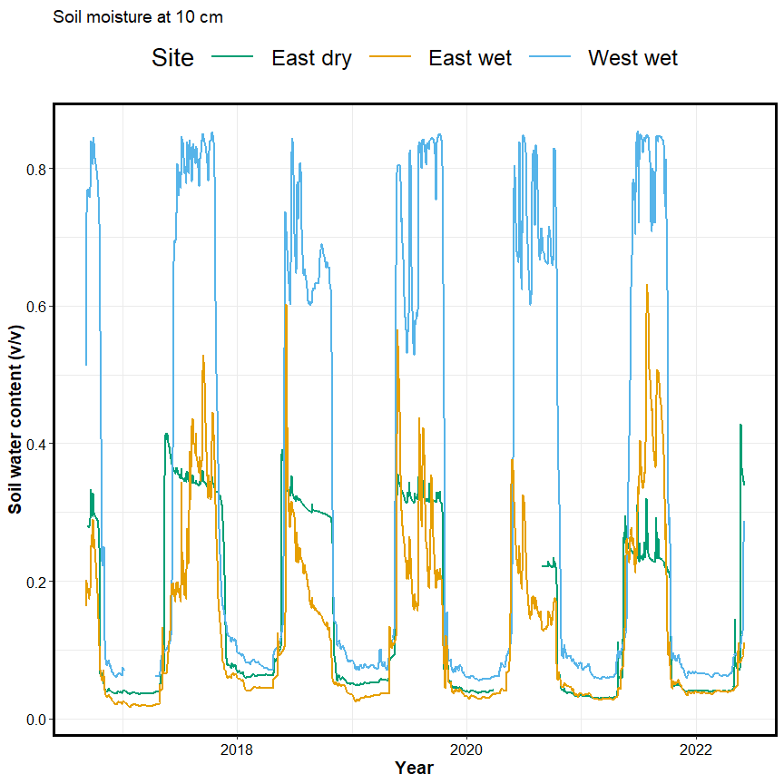

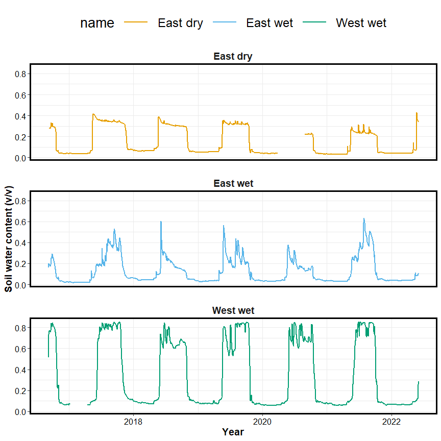

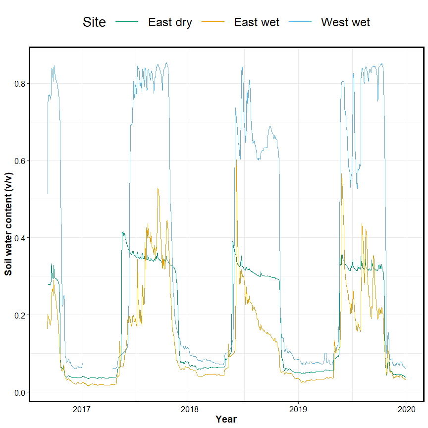

## Tree location

**click to open**

## N displayed by form for 2017-2019

**click to open**

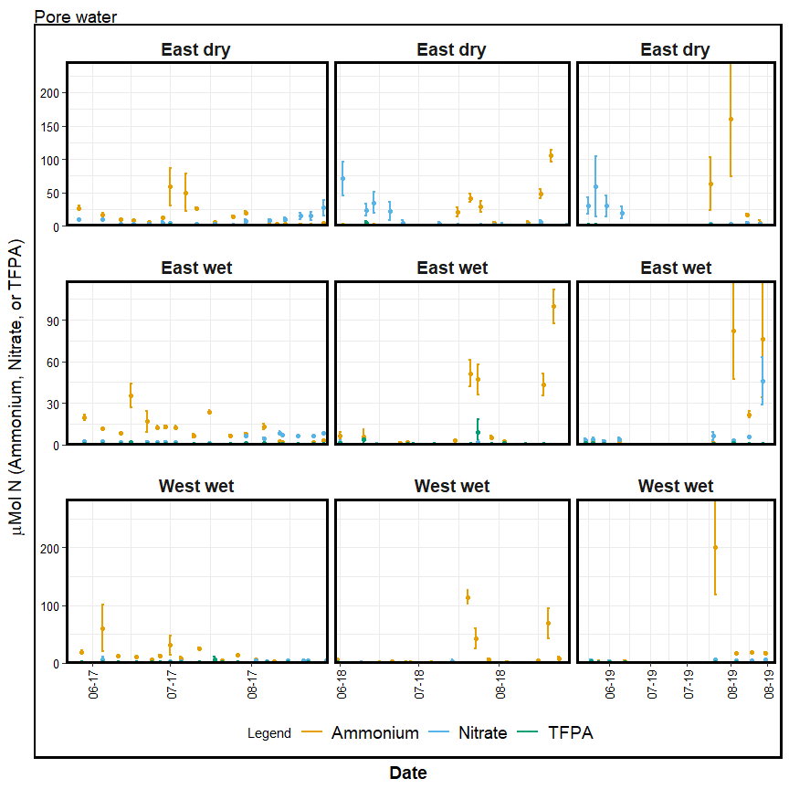

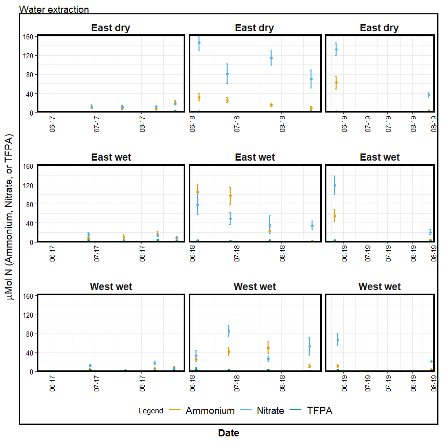

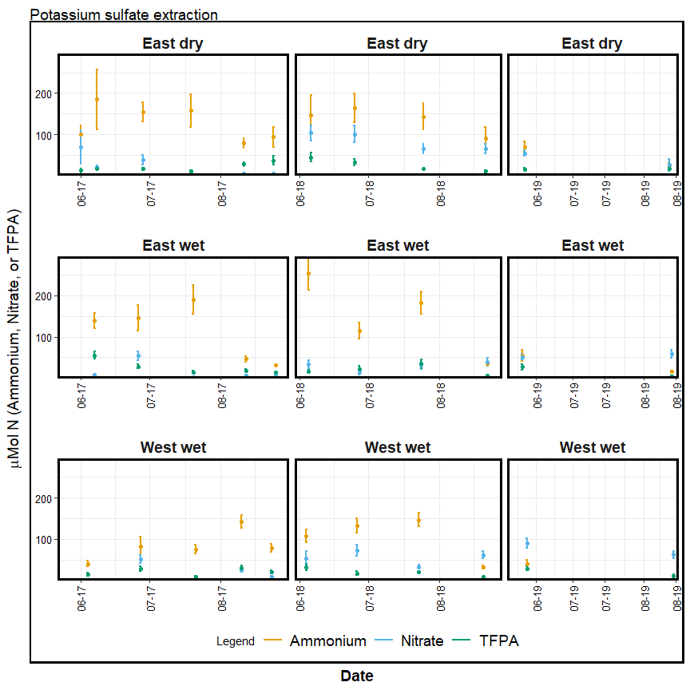

## Soil pH

**click to open**

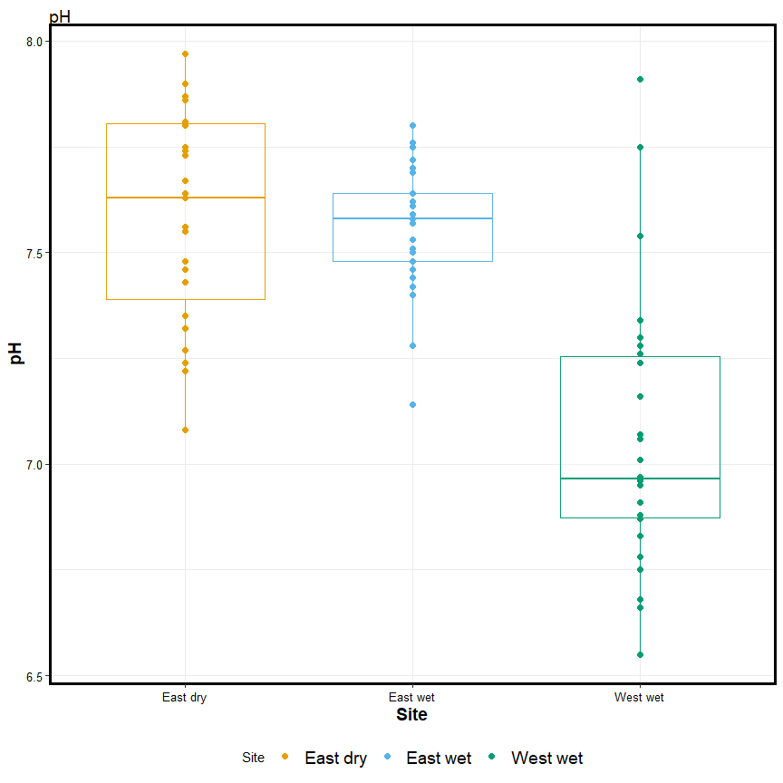

## Soil Precip

**click to open**

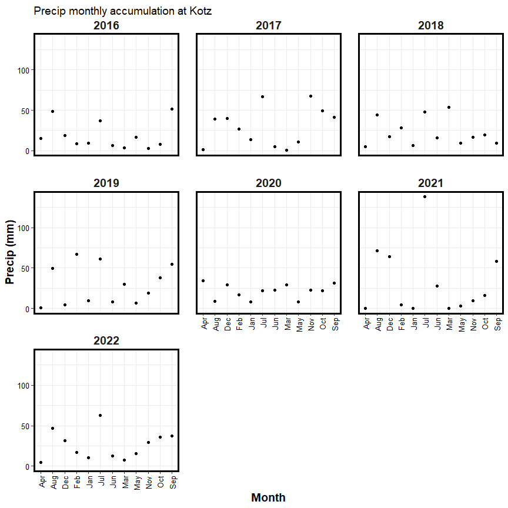

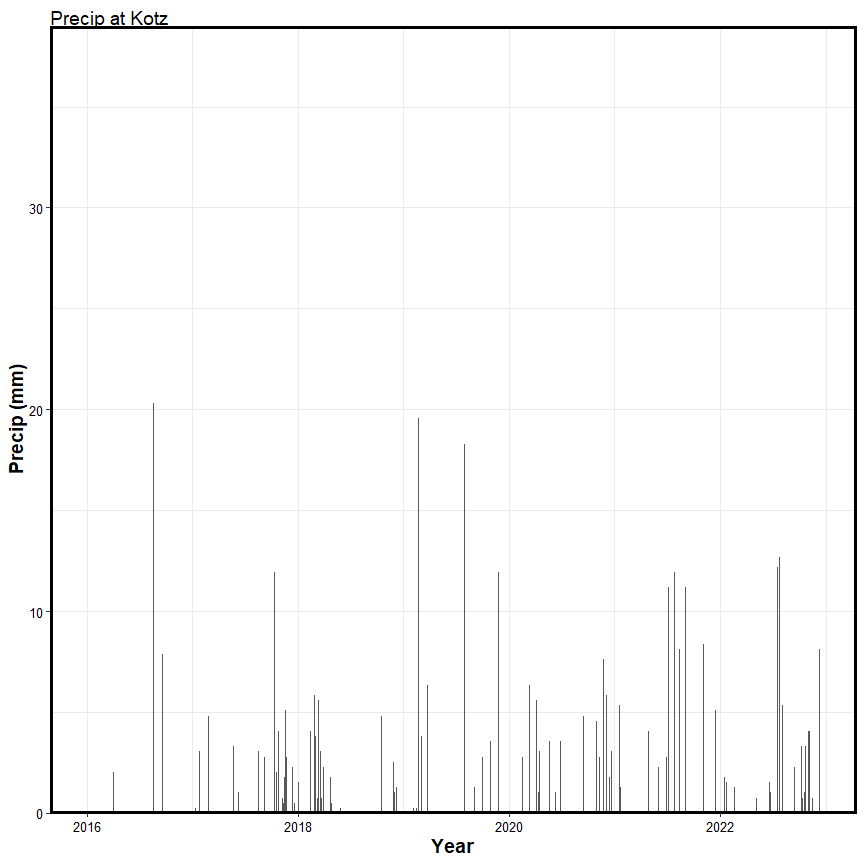

## Snowfence Vs. Control

**click to open**

#### Extracts snowfence vs control:

**click to open**

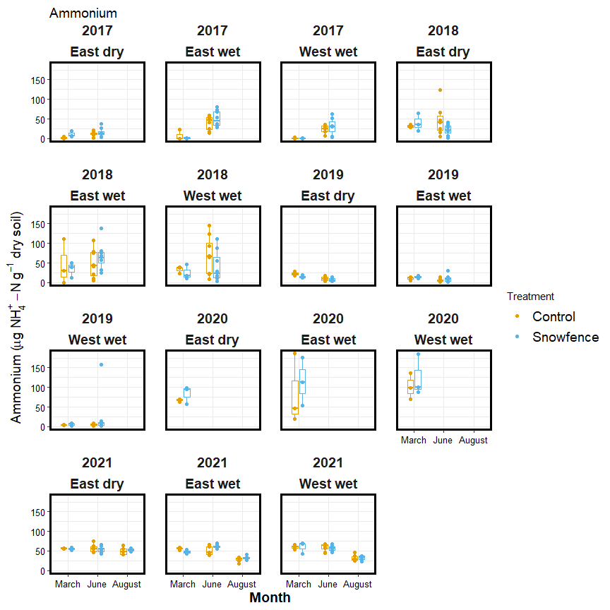

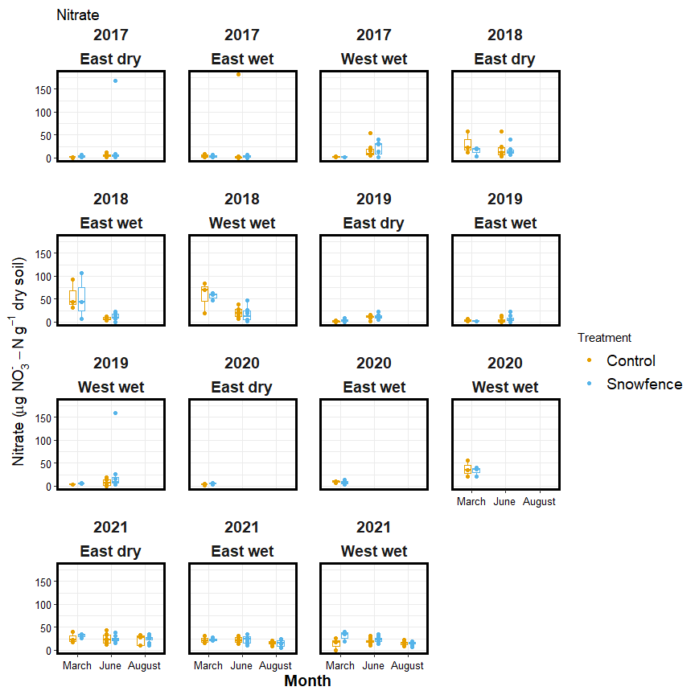

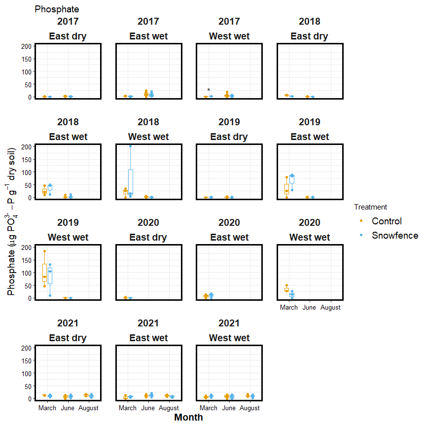

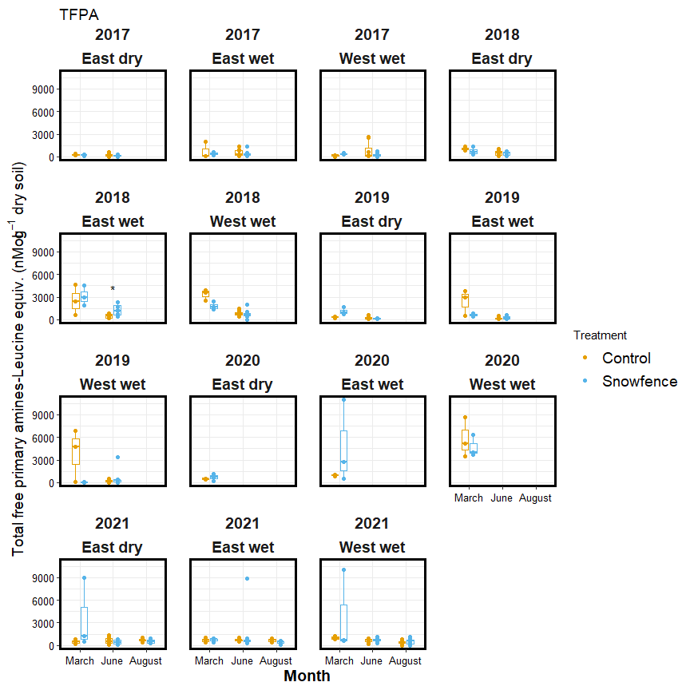

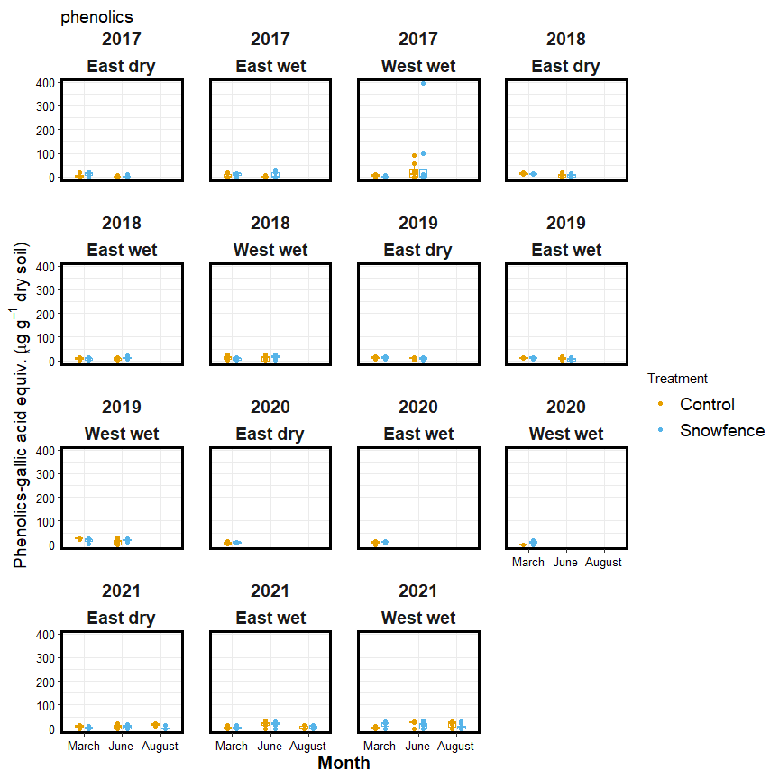

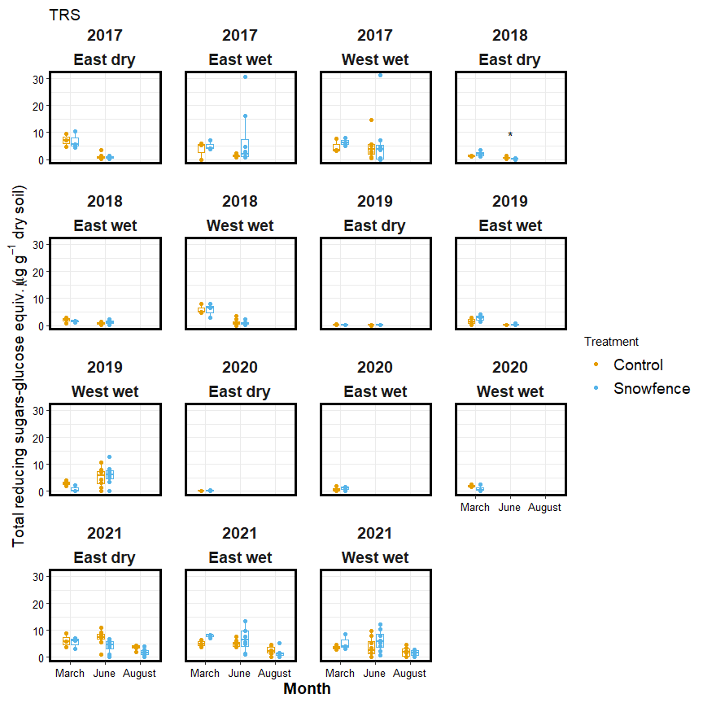

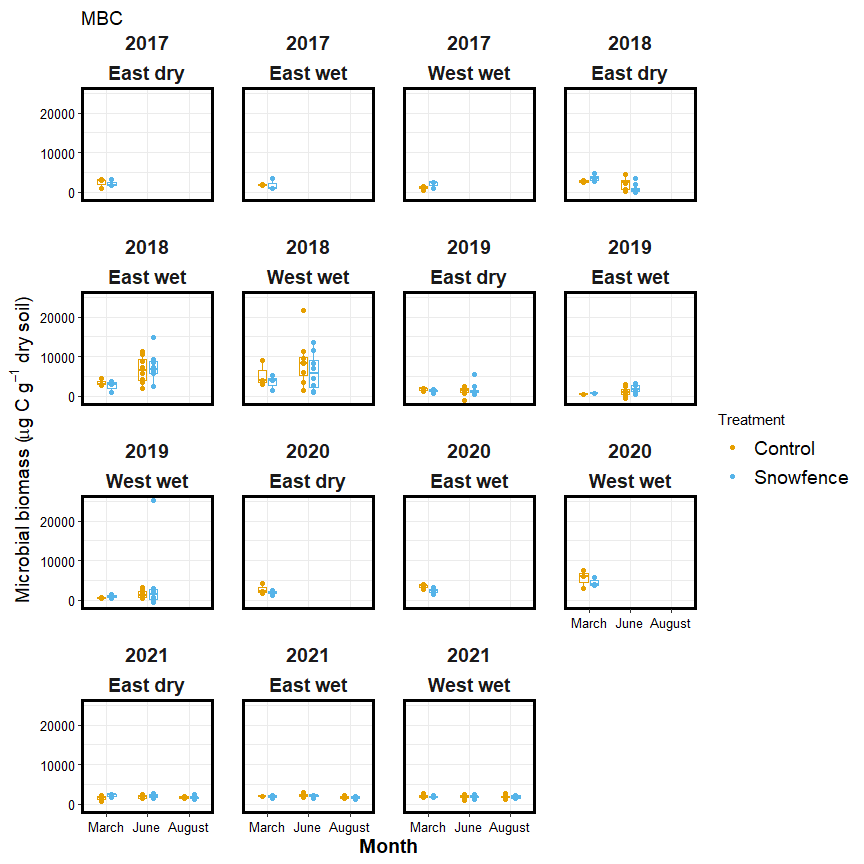

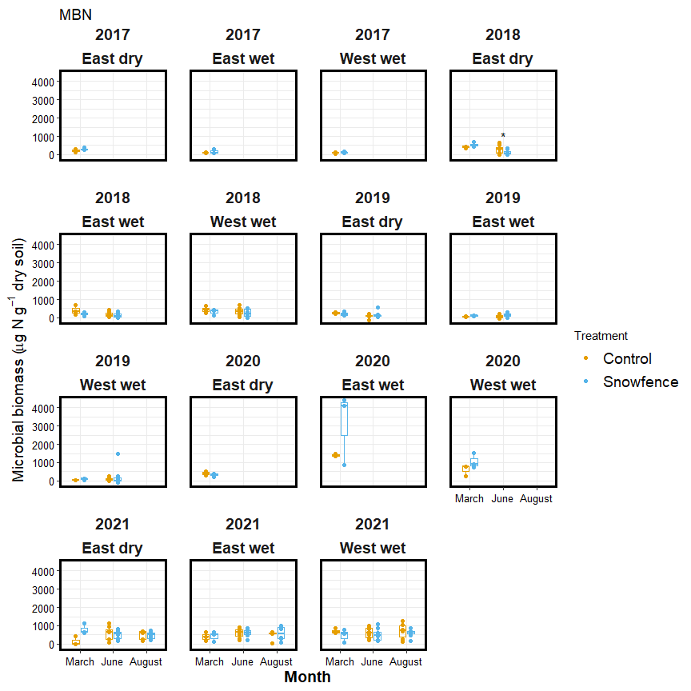

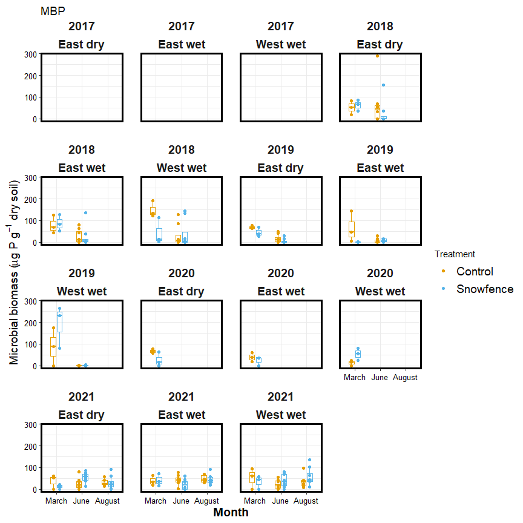

#### Anova results

**click to open ANOVA results**

[output not shown]

All comparisons

| analyte | Site | YEAR | TIME | p.value | asterisk |
| --- | --- | --- | --- | --- | --- |
| MBC | East dry | 2017 | Late Winter | 0.8767061 | NA |
| MBC | East dry | 2018 | Early Spring | 0.0723087 | NA |
| MBC | East dry | 2019 | Early Spring | 0.5367112 | NA |
| MBC | East wet | 2017 | Late Winter | 0.9242528 | NA |
| MBC | East wet | 2018 | Early Spring | 0.6309733 | NA |
| MBC | East wet | 2019 | Early Spring | 0.1736374 | NA |
| MBC | West wet | 2017 | Late Winter | 0.2351039 | NA |
| MBC | West wet | 2018 | Early Spring | 0.3767047 | NA |
| MBC | West wet | 2019 | Early Spring | 0.4034522 | NA |
| MBN | East dry | 2017 | Late Winter | 0.2733834 | NA |
| MBN | East dry | 2018 | Early Spring | 0.0459993 | * |
| MBN | East dry | 2019 | Early Spring | 0.3603539 | NA |
| MBN | East wet | 2017 | Late Winter | 0.4577312 | NA |
| MBN | East wet | 2018 | Early Spring | 0.5318262 | NA |
| MBN | East wet | 2019 | Early Spring | 0.1827473 | NA |
| MBN | West wet | 2017 | Late Winter | 0.4644693 | NA |
| MBN | West wet | 2018 | Early Spring | 0.4257308 | NA |
| MBN | West wet | 2019 | Early Spring | 0.5062197 | NA |
| NH4 | East dry | 2017 | Late Winter | 0.1265287 | NA |
| NH4 | East dry | 2018 | Early Spring | 0.1018585 | NA |
| NH4 | East dry | 2019 | Early Spring | 0.3190037 | NA |
| NH4 | East wet | 2017 | Late Winter | 0.4228383 | NA |
| NH4 | East wet | 2018 | Early Spring | 0.3189400 | NA |
| NH4 | East wet | 2019 | Early Spring | 0.2587825 | NA |
| NH4 | West wet | 2017 | Late Winter | 0.6445248 | NA |
| NH4 | West wet | 2018 | Early Spring | 0.2476791 | NA |
| NH4 | West wet | 2019 | Early Spring | 0.2868158 | NA |
| NO3 | East dry | 2017 | Late Winter | 0.2067186 | NA |
| NO3 | East dry | 2018 | Early Spring | 0.5964418 | NA |
| NO3 | East dry | 2019 | Early Spring | 0.5464968 | NA |

[output cut: 87 more lines]

## Seasonal (Pore water and extractions)

**click to open**

#### Potassium sulfate extractable concentrations:

**click to open**

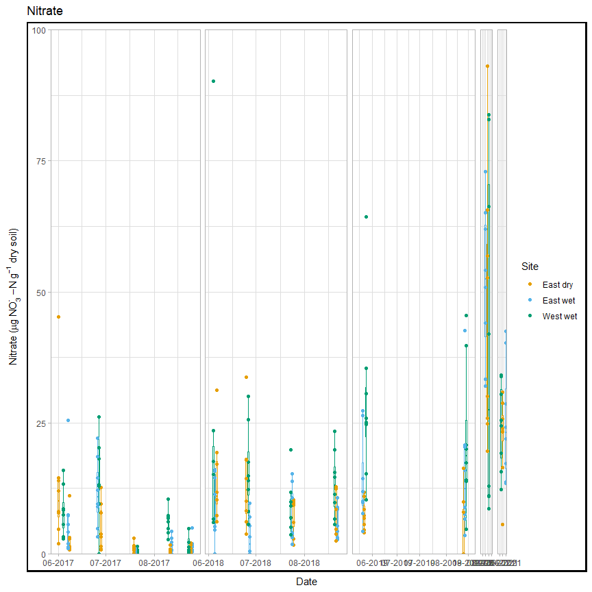

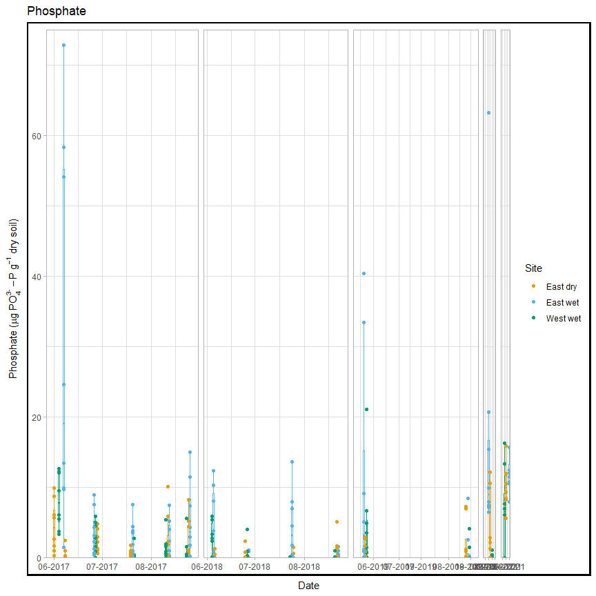

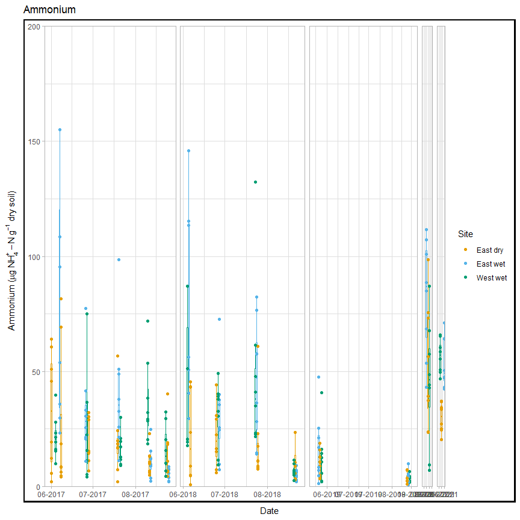

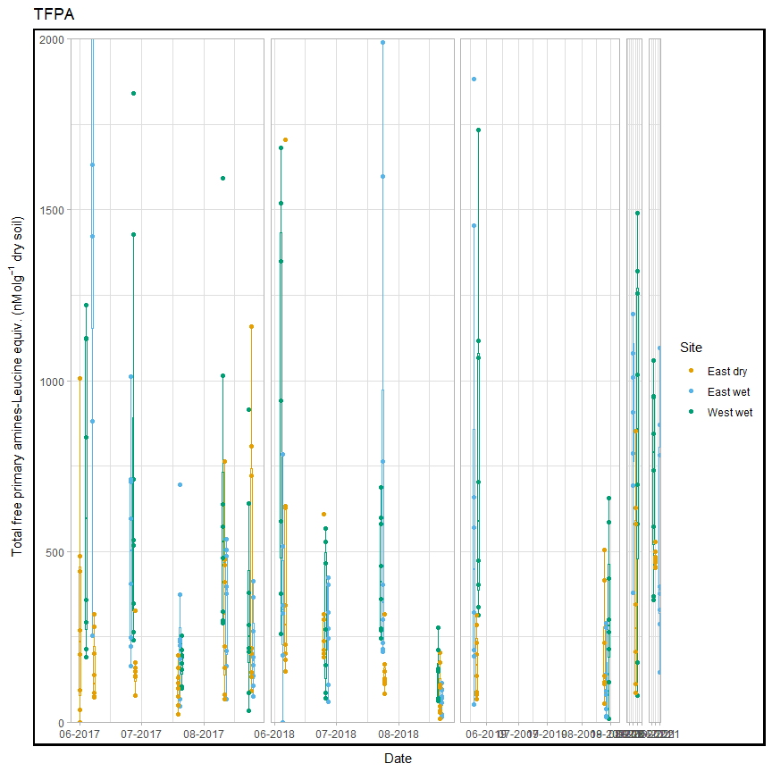

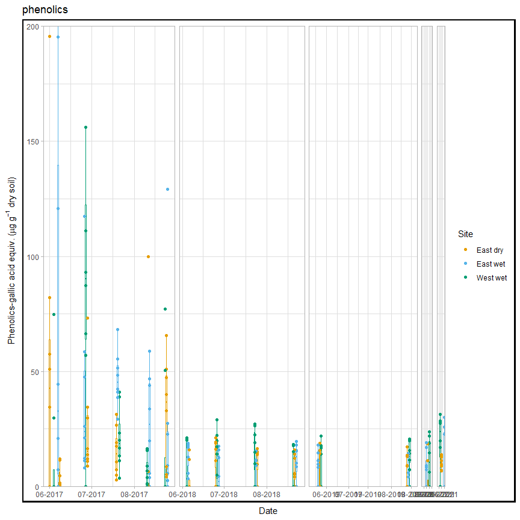

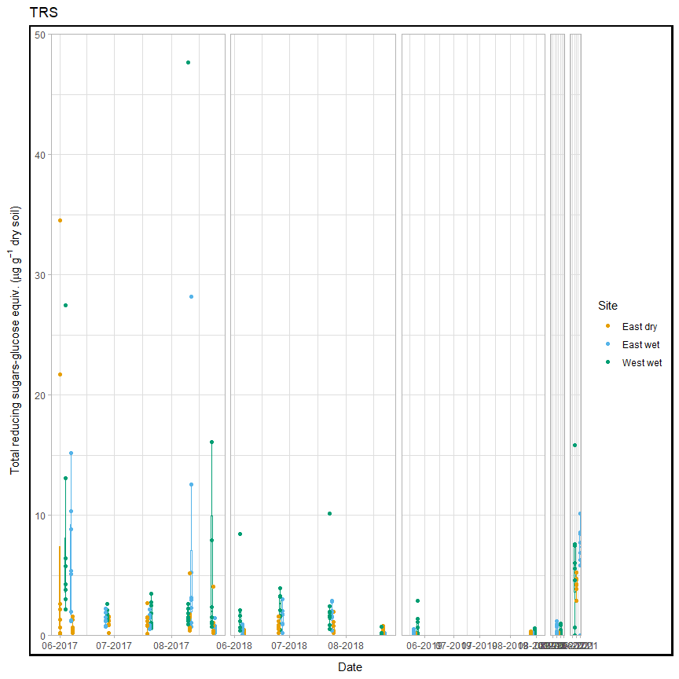

###### Extractable ANOVA:

**click to open**

| analyte | term | df | sumsq | meansq | statistic | p.value | asterisk |
| --- | --- | --- | --- | --- | --- | --- | --- |
| NH4 | MONTH | 1 | 3.814272e+03 | 3.814272e+03 | 4.4976102 | 0.0347463 | * |
| NH4 | YEAR | 1 | 9.567169e+03 | 9.567169e+03 | 11.2811565 | 0.0008820 | * |
| NH4 | Site | 2 | 1.825521e+04 | 9.127604e+03 | 10.7628418 | 0.0000304 | * |
| NH4 | MONTH:YEAR | 1 | 2.192026e+04 | 2.192026e+04 | 25.8473424 | 0.0000006 | * |
| NH4 | MONTH:Site | 2 | 5.353843e+03 | 2.676921e+03 | 3.1565002 | 0.0439641 | * |
| NH4 | YEAR:Site | 2 | 2.848357e+02 | 1.424178e+02 | 0.1679324 | 0.8454888 | NA |
| NH4 | MONTH:YEAR:Site | 2 | 1.691549e+04 | 8.457744e+03 | 9.9729752 | 0.0000637 | * |
| NH4 | Residuals | 306 | 2.595083e+05 | 8.480663e+02 | NA | NA | NA |
| NO3 | MONTH | 1 | 2.052035e+03 | 2.052035e+03 | 15.7477637 | 0.0000902 | * |
| NO3 | YEAR | 1 | 2.482835e+04 | 2.482835e+04 | 190.5381688 | 0.0000000 | * |
| NO3 | Site | 2 | 1.406268e+03 | 7.031341e+02 | 5.3960035 | 0.0049765 | * |
| NO3 | MONTH:YEAR | 1 | 1.033156e+04 | 1.033156e+04 | 79.2866169 | 0.0000000 | * |
| NO3 | MONTH:Site | 2 | 7.131231e+02 | 3.565616e+02 | 2.7363306 | 0.0663939 | NA |
| NO3 | YEAR:Site | 2 | 1.874237e+02 | 9.371184e+01 | 0.7191650 | 0.4879804 | NA |
| NO3 | MONTH:YEAR:Site | 2 | 1.351545e+02 | 6.757725e+01 | 0.5186025 | 0.5958743 | NA |
| NO3 | Residuals | 306 | 3.987378e+04 | 1.303065e+02 | NA | NA | NA |
| PO4 | MONTH | 1 | 2.591913e+02 | 2.591913e+02 | 4.3218962 | 0.0384632 | * |
| PO4 | YEAR | 1 | 5.303600e+02 | 5.303600e+02 | 8.8435092 | 0.0031768 | * |
| PO4 | Site | 2 | 1.843783e+03 | 9.218915e+02 | 15.3721174 | 0.0000004 | * |
| PO4 | MONTH:YEAR | 1 | 1.880597e+02 | 1.880597e+02 | 3.1358088 | 0.0775924 | NA |
| PO4 | MONTH:Site | 2 | 1.909407e+02 | 9.547037e+01 | 1.5919246 | 0.2052255 | NA |
| PO4 | YEAR:Site | 2 | 9.088123e+01 | 4.544062e+01 | 0.7577014 | 0.4696258 | NA |
| PO4 | MONTH:YEAR:Site | 2 | 8.080322e+02 | 4.040161e+02 | 6.7367835 | 0.0013716 | * |
| PO4 | Residuals | 304 | 1.823139e+04 | 5.997166e+01 | NA | NA | NA |
| TFPA | MONTH | 1 | 2.023341e+06 | 2.023341e+06 | 4.3566051 | 0.0377038 | * |
| TFPA | YEAR | 1 | 4.339456e+05 | 4.339456e+05 | 0.9343602 | 0.3345059 | NA |
| TFPA | Site | 2 | 8.345488e+06 | 4.172744e+06 | 8.9846432 | 0.0001621 | * |
| TFPA | MONTH:YEAR | 1 | 4.981306e+06 | 4.981306e+06 | 10.7256174 | 0.0011795 | * |
| TFPA | MONTH:Site | 2 | 2.123637e+06 | 1.061819e+06 | 2.2862799 | 0.1034006 | NA |
| TFPA | YEAR:Site | 2 | 9.610848e+05 | 4.805424e+05 | 1.0346913 | 0.3565922 | NA |
| TFPA | MONTH:YEAR:Site | 2 | 8.058023e+06 | 4.029012e+06 | 8.6751619 | 0.0002171 | * |
| TFPA | Residuals | 302 | 1.402581e+08 | 4.644307e+05 | NA | NA | NA |
| TRS | MONTH | 1 | 1.103491e+02 | 1.103491e+02 | 5.1331611 | 0.0241715 | * |
| TRS | YEAR | 1 | 9.791553e+00 | 9.791553e+00 | 0.4554783 | 0.5002544 | NA |
| TRS | Site | 2 | 1.599703e+02 | 7.998517e+01 | 3.7207078 | 0.0253193 | * |
| TRS | MONTH:YEAR | 1 | 1.419461e+02 | 1.419461e+02 | 6.6029744 | 0.0106542 | * |
| TRS | MONTH:Site | 2 | 3.638168e+00 | 1.819084e+00 | 0.0846192 | 0.9188836 | NA |
| TRS | YEAR:Site | 2 | 3.383861e+01 | 1.691931e+01 | 0.7870434 | 0.4561078 | NA |
| TRS | MONTH:YEAR:Site | 2 | 5.615621e+01 | 2.807811e+01 | 1.3061226 | 0.2723740 | NA |
| TRS | Residuals | 306 | 6.578173e+03 | 2.149730e+01 | NA | NA | NA |
| phenolics | MONTH | 1 | 7.698844e+03 | 7.698844e+03 | 7.9247529 | 0.0051915 | * |
| phenolics | YEAR | 1 | 1.903323e+04 | 1.903323e+04 | 19.5917323 | 0.0000133 | * |
| phenolics | Site | 2 | 4.277489e+03 | 2.138744e+03 | 2.2015022 | 0.1123805 | NA |
| phenolics | MONTH:YEAR | 1 | 3.382618e+03 | 3.382618e+03 | 3.4818755 | 0.0629978 | NA |
| phenolics | MONTH:Site | 2 | 1.866633e+03 | 9.333165e+02 | 0.9607031 | 0.3837710 | NA |
| phenolics | YEAR:Site | 2 | 3.683140e+03 | 1.841570e+03 | 1.8956076 | 0.1519812 | NA |
| phenolics | MONTH:YEAR:Site | 2 | 2.479668e+03 | 1.239834e+03 | 1.2762146 | 0.2805682 | NA |
| phenolics | Residuals | 307 | 2.982484e+05 | 9.714932e+02 | NA | NA | NA |

#### Water extractable concentrations:

**click to open**

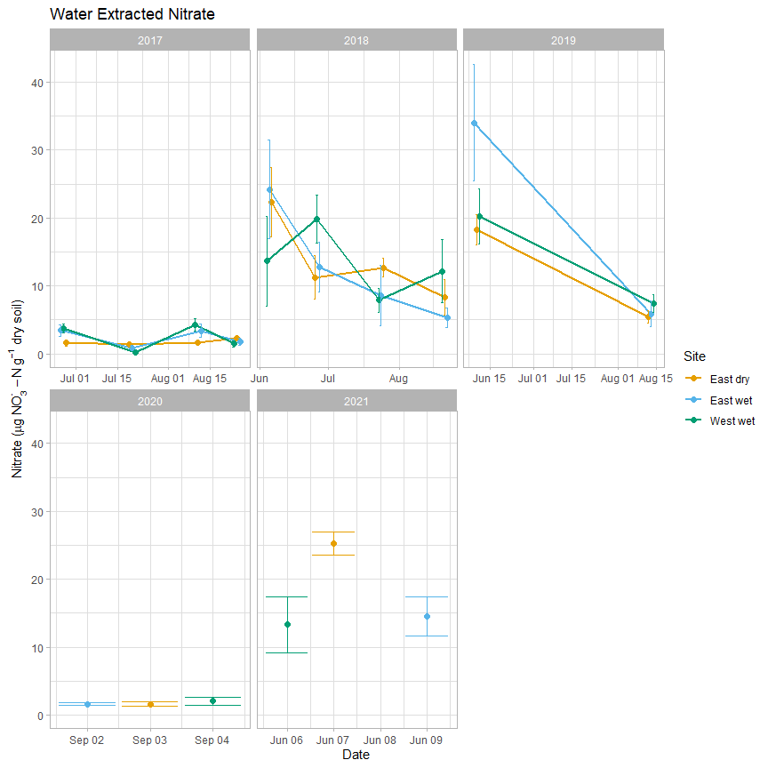

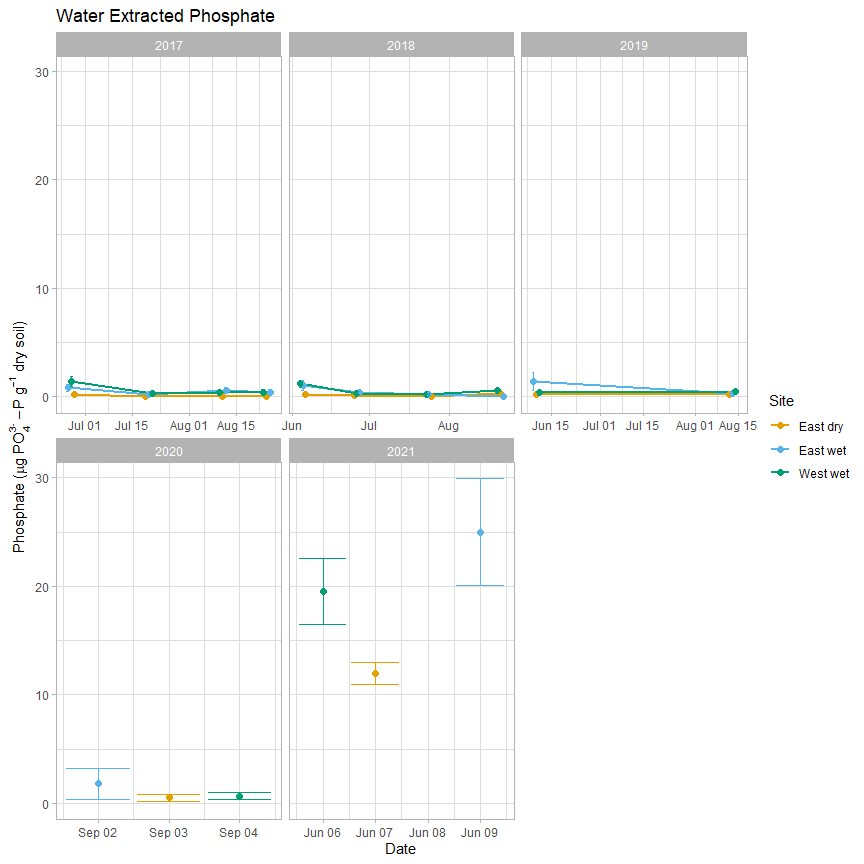

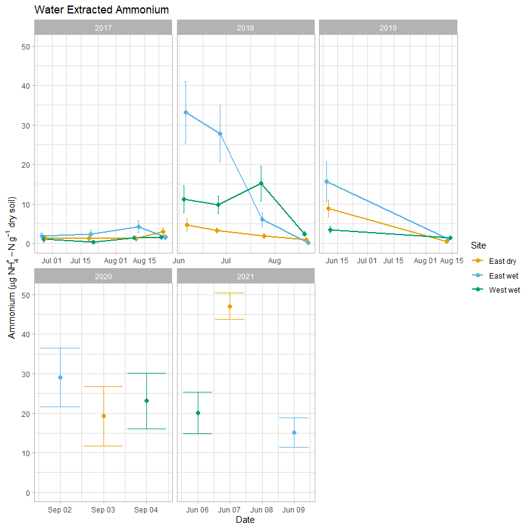

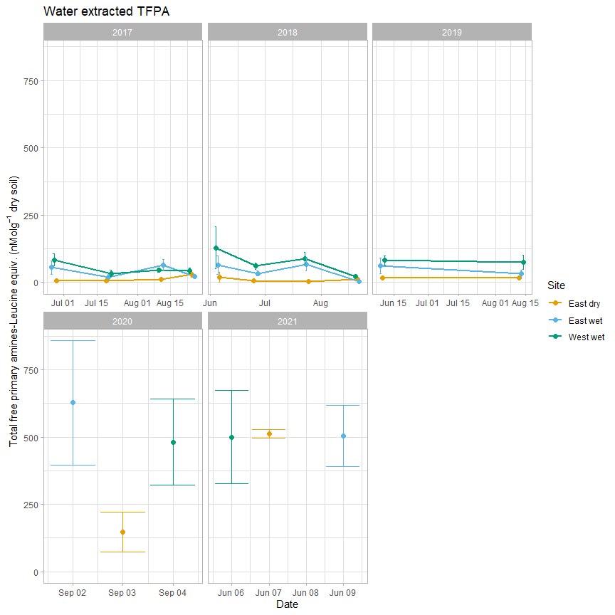

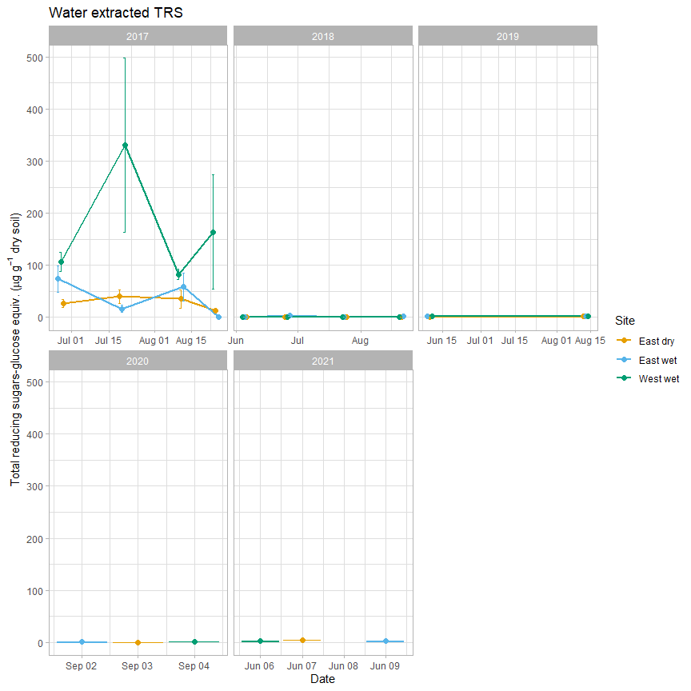

###### Water extractable ANOVA:

**click to open**

| analyte | term | df | sumsq | meansq | statistic | p.value | asterisk |
| --- | --- | --- | --- | --- | --- | --- | --- |
| NH4.H2O | MONTH | 1 | 9.298845e+02 | 9.298845e+02 | 7.3387998 | 0.0071764 | * |
| NH4.H2O | YEAR | 1 | 1.497415e+04 | 1.497415e+04 | 118.1784590 | 0.0000000 | * |
| NH4.H2O | Site | 2 | 7.858396e+02 | 3.929198e+02 | 3.1009870 | 0.0465997 | * |
| NH4.H2O | MONTH:YEAR | 1 | 3.213494e+02 | 3.213494e+02 | 2.5361418 | 0.1124278 | NA |
| NH4.H2O | MONTH:Site | 2 | 4.144057e+02 | 2.072028e+02 | 1.6352785 | 0.1968083 | NA |
| NH4.H2O | YEAR:Site | 2 | 1.811201e+03 | 9.056004e+02 | 7.1471454 | 0.0009437 | * |
| NH4.H2O | MONTH:YEAR:Site | 2 | 3.344212e+03 | 1.672106e+03 | 13.1965320 | 0.0000034 | * |
| NH4.H2O | Residuals | 272 | 3.446457e+04 | 1.267080e+02 | NA | NA | NA |
| NO3.H2O | MONTH | 1 | 7.624211e+03 | 7.624211e+03 | 81.3091284 | 0.0000000 | * |
| NO3.H2O | YEAR | 1 | 3.154437e+03 | 3.154437e+03 | 33.6407984 | 0.0000000 | * |
| NO3.H2O | Site | 2 | 3.434327e+01 | 1.717163e+01 | 0.1831285 | 0.8327637 | NA |
| NO3.H2O | MONTH:YEAR | 1 | 2.798718e+02 | 2.798718e+02 | 2.9847191 | 0.0851889 | NA |
| NO3.H2O | MONTH:Site | 2 | 2.679324e+02 | 1.339662e+02 | 1.4286953 | 0.2414137 | NA |
| NO3.H2O | YEAR:Site | 2 | 2.409066e+02 | 1.204533e+02 | 1.2845857 | 0.2784388 | NA |
| NO3.H2O | MONTH:YEAR:Site | 2 | 1.575699e+02 | 7.878496e+01 | 0.8402097 | 0.4327371 | NA |
| NO3.H2O | Residuals | 272 | 2.550495e+04 | 9.376821e+01 | NA | NA | NA |
| PO4.H2O | MONTH | 1 | 7.901527e+02 | 7.901527e+02 | 55.1569722 | 0.0000000 | * |
| PO4.H2O | YEAR | 1 | 3.506394e+03 | 3.506394e+03 | 244.7654111 | 0.0000000 | * |
| PO4.H2O | Site | 2 | 1.257450e+02 | 6.287252e+01 | 4.3888450 | 0.0133096 | * |
| PO4.H2O | MONTH:YEAR | 1 | 1.527105e+03 | 1.527105e+03 | 106.6002833 | 0.0000000 | * |
| PO4.H2O | MONTH:Site | 2 | 7.105184e+01 | 3.552592e+01 | 2.4799030 | 0.0856503 | NA |
| PO4.H2O | YEAR:Site | 2 | 2.871611e+02 | 1.435805e+02 | 10.0227053 | 0.0000632 | * |
| PO4.H2O | MONTH:YEAR:Site | 2 | 1.106507e+02 | 5.532534e+01 | 3.8620104 | 0.0221926 | * |
| PO4.H2O | Residuals | 271 | 3.882218e+03 | 1.432553e+01 | NA | NA | NA |
| TFPA.H2O | MONTH | 1 | 3.591241e+04 | 3.591241e+04 | 0.9788345 | 0.3233660 | NA |
| TFPA.H2O | YEAR | 1 | 5.162025e+06 | 5.162025e+06 | 140.6969962 | 0.0000000 | * |
| TFPA.H2O | Site | 2 | 3.084535e+05 | 1.542267e+05 | 4.2036285 | 0.0159233 | * |
| TFPA.H2O | MONTH:YEAR | 1 | 9.285573e+01 | 9.285573e+01 | 0.0025309 | 0.9599139 | NA |
| TFPA.H2O | MONTH:Site | 2 | 1.917958e+05 | 9.589792e+04 | 2.6138091 | 0.0750944 | NA |
| TFPA.H2O | YEAR:Site | 2 | 1.105959e+05 | 5.529795e+04 | 1.5072097 | 0.2233715 | NA |
| TFPA.H2O | MONTH:YEAR:Site | 2 | 3.428732e+05 | 1.714366e+05 | 4.6727032 | 0.0101101 | * |
| TFPA.H2O | Residuals | 272 | 9.979395e+06 | 3.668895e+04 | NA | NA | NA |
| TRS.H2O | MONTH | 1 | 4.034054e+02 | 4.034054e+02 | 0.0363724 | 0.8488908 | NA |
| TRS.H2O | YEAR | 1 | 1.945807e+05 | 1.945807e+05 | 17.5440491 | 0.0000380 | * |
| TRS.H2O | Site | 2 | 1.391277e+05 | 6.956386e+04 | 6.2721104 | 0.0021727 | * |
| TRS.H2O | MONTH:YEAR | 1 | 4.444839e+03 | 4.444839e+03 | 0.4007615 | 0.5272281 | NA |
| TRS.H2O | MONTH:Site | 2 | 2.957180e+03 | 1.478590e+03 | 0.1333146 | 0.8752468 | NA |
| TRS.H2O | YEAR:Site | 2 | 1.380024e+05 | 6.900120e+04 | 6.2213789 | 0.0022807 | * |
| TRS.H2O | MONTH:YEAR:Site | 2 | 9.925228e+03 | 4.962614e+03 | 0.4474459 | 0.6397285 | NA |
| TRS.H2O | Residuals | 272 | 3.016747e+06 | 1.109098e+04 | NA | NA | NA |